# **ECONOMETRIA ESPACIAL E TEMPORAL**

**Mestrado em Ciência de Dados para Ciências Sociais**

**Homework Assignment 1**

**Grupo 1**: Lúcio Serôdio, 123991 || Magda Matias, 50091 || Rafael Santos, 118336

# Introdução

Pretende-se explicar os preços médios de venda de habitação da Região do Algarve. A escala das unidades de análise são as freguesias da região em estudo e o ano de estudo será o ano 2021, que é o ano dos últimos censos. Por uma questão de coerência temporal, vamos utilizar dados de 2021.

**Objectivo:**  
Saber quais as freguesias com preços mais elevados e o quanto as variáveis explicativas influenciam sobre eles.

**Indicadores:**

1- **"Valor mediano das vendas por m2 de alojamentos familiares (Metodologia 2022 - €) por Localização geográfica (NUTS - 2024) e Categoria do alojamento familiar; Anual"**: será identificado como **df_vendas**;

2- **"Valor médio mensal das rendas dos alojamentos familiares clássicos arrendados (€) por Localização geográfica à data dos Censos (2021) (NUTS - 2013); Decenal"**: será identificado como **df_rendas**;

3 - **"Valor mediano das vendas por m2 de alojamentos familiares por Localização geográfica (NUTS - 2013) e Tipologia do fogo; Anual"** : será identificado como **df_vendas_tipo** ;

# Pergunta de Investigação e Relevância do Estudo

A questão central deste estudo foi:  
**Quais são as freguesias do Algarve com os preços de habitação mais elevados e de que forma as variáveis explicativas, como localização, tipologia e contexto da vizinhança, influenciam esses valores?**

## Por que este estudo é relevante?

O mercado imobiliário em Portugal, e particularmente na região do Algarve, tem registado um crescimento significativo, impulsionado pelo turismo e pela alta procura por residências. Compreender os fatores que afetam os preços das habitações é essencial para:

- **Investidores**: Identificar oportunidades de investimento e áreas de valorização.
- **Planeamento do território e políticas públicas**: Planear o desenvolvimento urbano de forma sustentável e formular políticas habitacionais e de ordenamento do território.
- **Cidadãos**: para poderem ter melhor e mais acesso à habitação.

## A Importância da Análise Espacial e do Contexto Local

Os preços dos imóveis não são determinados apenas por características intrínsecas, como tamanho ou tipologia. Fatores externos, como a **localização**, a **vizinhança** e a **proximidade de infraestruturas**, desempenham um papel crucial.

A **análise espacial** permite captar esses padrões, identificando áreas de valorização e possíveis **clusters** (agrupamentos) de preços elevados ou reduzidos. Isso revela como a valorização imobiliária está distribuída no território. Além disso, ao considerar o **contexto da vizinhança**, é possível entender como fatores locais, como a qualidade das casas próximas e a dinâmica da comunidade, influenciam os valores das propriedades.

## O Índice de Moran e LISA: Por que são importantes para este estudo?

Para compreender a **dependência espacial** dos preços das habitações no Algarve, utilizamos dois métodos estatísticos fundamentais: o **Índice de Moran Global** e o **Índice de Moran Local (LISA)**. Essas ferramentas permitem analisar padrões de agrupamento e identificar como os preços das habitações se relacionam espacialmente.

### Índice de Moran Global

O Moran Global mede a **autocorrelação espacial**, ou seja, se freguesias com preços de habitação semelhantes estão agrupadas no território ou se a distribuição ocorre de forma aleatória.

- Um **valor alto** de Moran indica que freguesias próximas tendem a ter preços similares, sugerindo a existência de **clusters espaciais**.
- Um **valor baixo** sugere uma distribuição mais dispersa, sem padrões claros de agrupamento.

No contexto deste estudo, o Moran Global ajudou a confirmar se os preços das habitações no Algarve seguem tendências espaciais bem definidas, como a concentração de valores elevados nas zonas costeiras.

### Índice de Moran Local (LISA)

O LISA vai além do Moran Global, permitindo identificar **clusters específicos** de alta ou baixa valorização imobiliária. Com essa análise, foi possível:

- Localizar freguesias com preços **muito acima da média regional**, indicando zonas de alta valorização.
- Identificar freguesias com preços **muito abaixo da média**, sugerindo possíveis áreas de desinvestimento ou menor atratividade (fatores populacionais, a zona interior da região algarvia tem características comuns às da região do Baixo Alentejo)

# Configurações

```python
import os
import sys
import importlib
from pathlib import Path

import pandas as pd
import geopandas as gpd

import numpy as np

## Matrizes vizinhança
import scipy
import seaborn as sns
import mapclassify as mc
import libpysal as lps
from pysal.lib import weights
from shapely.geometry import Point



import matplotlib.pyplot as plt
import contextily as cx

from matplotlib.colors import ListedColormap

# Autocorrelações
from esda.moran import Moran
from esda.moran import Moran_Local
from splot.esda import moran_scatterplot
from splot.esda import lisa_cluster
```

```python
gpd.options.io_engine = "pyogrio"
os.environ["PYOGRIO_USE_ARROW"] = "1"

from pyogrio import list_layers
```

## Definição dos diretórios de trabalho

```python
from pathlib import Path

# Find the project root (assuming marker-based or script-relative path)
def find_project_root(marker="README.md"):
    current_dir = Path.cwd()
    while current_dir != current_dir.parent:  # Traverse up until root
        if (current_dir / marker).exists():
            return current_dir
        current_dir = current_dir.parent
    raise FileNotFoundError(f"Marker '{marker}' not found in any parent directory.")

project_root = find_project_root()
sys.path.append(str(project_root))

# Or use a relative path: project_root = Path(__file__).resolve().parent.parent
os.chdir(project_root)
print(f"Working directory set to: {project_root}")
```

```
Working directory set to: c:\Users\magda\OneDrive - Universidade de Aveiro\Universidade _ Mestrado_CDCS\Primeiro_Ano\2_Semestre\ETE\HA1_Grupo1
```

```python
module_path = os.path.abspath(os.path.join(r'.\src'))
if module_path not in sys.path:
    sys.path.append(module_path)

module_path

import utils.utils_ete2425
```

```python
# Verificar acesso ao utils
import sys
sys.path.append('src/utils/utils_ete2425.py')
```

## Diretórios de dados

### CAOP

```python
print(list_layers('data\input\CAOP2023\Continente_CAOP2023.gpkg'))
```

```
[['Cont_AAD_CAOP2023' 'MultiPolygon']
 ['Cont_Dist_CAOP2023' 'MultiPolygon']
 ['Cont_Freg_CAOP2023' 'MultiPolygon']
 ['Cont_Mun_CAOP2023' 'MultiPolygon']
 ['Cont_NUTSI_CAOP2023' 'MultiPolygon']
 ['Cont_NUTSII_CAOP2023' 'MultiPolygon']
 ['Cont_NUTSIII_CAOP2023' 'MultiPolygon']
 ['Cont_Troco_CAOP2023' 'MultiLineString']
 ['layer_styles' None]]
```

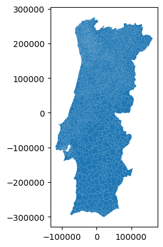

```python
shape_CAOP_FREGUESIAS = gpd.read_file(r'.\data\input' + r'\CAOP2023\Continente_CAOP2023.gpkg', layer = 'Cont_Freg_CAOP2023')
shape_CAOP_LIMITES = gpd.read_file(r'.\data\input' + r'\CAOP2023\Continente_CAOP2023.gpkg', layer = 'Cont_Troco_CAOP2023')

shape_CAOP_FREGUESIAS.plot()
```

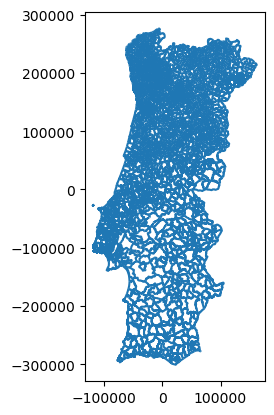

```python
shape_CAOP_LIMITES.plot()
```

```python
shape_CAOP_FREGUESIAS.columns
```

```
Index(['DICOFRE', 'Freguesia', 'Municipio', 'Distrito', 'Area_ha',
       'Des_Simpli', 'geometry'],
      dtype='object')
```

```python
shape_CAOP_FREGUESIAS.head(10)
```

|  | DICOFRE | Freguesia | Municipio | Distrito | Area_ha | Des_Simpli | geometry |
| --- | --- | --- | --- | --- | --- | --- | --- |
| 0 | 010103 | Aguada de Cima | Águeda | Aveiro | 2839.31 | Aguada de Cima | MULTIPOLYGON (((-22457.151 97217.803, -22423.8... |
| 1 | 010109 | Fermentelos | Águeda | Aveiro | 858.20 | Fermentelos | MULTIPOLYGON (((-31260.894 100010.838, -31262.... |
| 2 | 010112 | Macinhata do Vouga | Águeda | Aveiro | 3195.44 | Macinhata do Vouga | MULTIPOLYGON (((-20410.354 112211.523, -20409.... |
| 3 | 010121 | União das freguesias de Águeda e Borralha | Águeda | Aveiro | 3602.93 | Águeda e Borralha | MULTIPOLYGON (((-20314.596 103473.011, -20318.... |
| 4 | 010122 | União das freguesias de Barrô e Aguada de Baixo | Águeda | Aveiro | 1019.01 | Barrô e Aguada de Baixo | MULTIPOLYGON (((-27174.916 97248.214, -27162.9... |
| 5 | 010123 | União das freguesias de Belazaima do Chão, Cas... | Águeda | Aveiro | 8809.03 | Belazaima do Chão, Castanheira do Vouga e Agadão | MULTIPOLYGON (((-14839.48 103073.872, -14748.2... |
| 6 | 010124 | União das freguesias de Recardães e Espinhel | Águeda | Aveiro | 1991.78 | Recardães e Espinhel | MULTIPOLYGON (((-27984.277 101887.156, -28032.... |
| 7 | 010125 | União das freguesias de Travassô e Óis da Ribeira | Águeda | Aveiro | 1112.19 | Travassô e Óis da Ribeira | MULTIPOLYGON (((-27884.459 102870.137, -27884.... |
| 8 | 010127 | União das freguesias do Préstimo e Macieira de... | Águeda | Aveiro | 4172.64 | Préstimo e Macieira de Alcoba | MULTIPOLYGON (((-13637.188 109321.61, -13637.7... |
| 9 | 010202 | Alquerubim | Albergaria-a-Velha | Aveiro | 1535.86 | Alquerubim | MULTIPOLYGON (((-29041.318 108973.684, -29040.... |

```python
shape_CAOP_LIMITES.head(3)
```

|  | ID_TROCO | ENT_DIREIT | ENT_ESQUER | ICC | BST | MOL | COMP_m | geometry |
| --- | --- | --- | --- | --- | --- | --- | --- | --- |
| 0 | 20 | Sagres | Oceano Atlântico | PT | Definido | LIMITE E LINHA DE COSTA | 48.33 | MULTILINESTRING ((-68795.79 -293292.348, -6879... |
| 1 | 327 | Bordeira | Oceano Atlântico | PT | Definido | LIMITE E LINHA DE COSTA | 20.16 | MULTILINESTRING ((-69134.893 -274756.276, -691... |
| 2 | 424 | Rogil | Oceano Atlântico | PT | Definido | LIMITE E LINHA DE COSTA | 24.14 | MULTILINESTRING ((-60040.627 -250392.798, -600... |

### Restringir áreas e limites do CAOP à região do Algarve

Decidimos escolher a região do Algarve como área de estudo devido à sua relevância no mercado imobiliário português, caracterizando-se por ter uma forte procura turística e residencial, quer a nível nacional, quer internacional. A região apresenta variações significativas nos preços da habitação, influenciadas por fatores como a proximidade ao mar, acessibilidade, infraestruturas e presença de investidores estrangeiros. Além disso, a disponibilidade de dados oficiais detalhados permite uma análise espacial robusta, facilitando a identificação de padrões de dependência espacial.

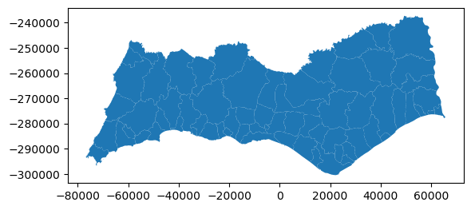

```python
#Areas
Algarve_CAOP_FREGUESIAS =  shape_CAOP_FREGUESIAS[shape_CAOP_FREGUESIAS['DICOFRE'].str.startswith('08')]

Algarve_CAOP_FREGUESIAS.plot()
```

```python
Algarve_CAOP_FREGUESIAS.head(3)
```

|  | DICOFRE | Freguesia | Municipio | Distrito | Area_ha | Des_Simpli | geometry |
| --- | --- | --- | --- | --- | --- | --- | --- |
| 1226 | 080102 | Guia | Albufeira | Faro | 2496.60 | Guia | MULTIPOLYGON (((-12970.384 -280121.571, -12970... |
| 1227 | 080103 | Paderne | Albufeira | Faro | 5256.17 | Paderne | MULTIPOLYGON (((-2072.376 -275271.238, -2066.6... |
| 1228 | 080104 | Ferreiras | Albufeira | Faro | 2195.96 | Ferreiras | MULTIPOLYGON (((-4475.16 -280601.518, -4479.37... |

```python
# Projeção geográfica do sistema de referenciação fornecido na BGRI2021 (EPSG:3763) para o sistema de referenciação
# utilizado na biblioteca "contextily" (EPSG:3857)
# A biblioteca "contextily" permite a sobreposição de mapas base (imagens de satélite, mapas de ruas, etc) sobre
# os nossos mapas / representações geométricas das nossas unidades de análise

Algarve_CAOP_FREGUESIAS_reproject = Algarve_CAOP_FREGUESIAS.to_crs(epsg=3857)
```

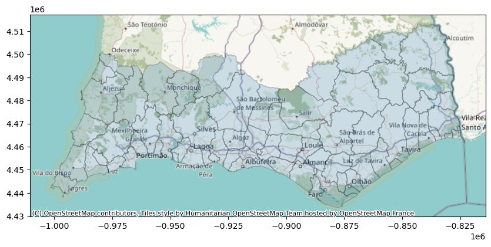

```python
# Adição de um mapa de fundo ao nosso mapa de subsecções estatísticas do Algarve
# Neste caso, associamos um mapa obtido no serviço OpenStreetMaps https://www.openstreetmap.org/

ax = Algarve_CAOP_FREGUESIAS_reproject.plot(figsize=(10, 10), alpha=0.2, edgecolor="k")
cx.add_basemap(ax)
```

### INE - Censos em geopackage do Algarve

```python
print(list_layers('data\BGRI21_150\BGRI21_150.gpkg'))
```

```
[['BGRI21_150' 'MultiPolygon']]
```

### INE - Censos e estatísticas 2021

#### Indicadores:

- Variável Dependente (Y): Preço mediano das vendas por m2 - Censos 2021

Mede a valorização da habitação e permite identificar a existência de padrões espaciais no mercado imobiliário.

- Variável Independente (X): Preço médio das vendas por tipologia

Captura variações nos preços por tipo de habitação, permitindo avaliar se a tipologia influencia o preço médio por m² de forma espacialmente diferenciada.

- Variável Independente (X): Valor médio das rendas

Permite analisar a relação entre preços de venda e arrendamento, avaliando se regiões com valores elevados de compra também apresentam rendas mais altas.

```python
# Carregar os dados

df_rendas = pd.read_excel('data/algarve/valor_medio_mensal_rendas_FREGUESIAS_2021.xls',dtype={'CODIGO': str})
df_vendas = pd.read_excel('data/algarve/valor_mediano_vendas_m2_FREGUESIAS_2021_a_2023.xls', dtype={'CODIGO': str})
df_vendas_tipo = pd.read_excel('data/algarve/valor_mediano_vendas_por_tipologia_FREGUESIAS_2021_a_2022.xls',dtype={'CODIGO': str})

df_vendas[['Localizacao', 'CODIGO']].head(3)
```

|  | Localizacao | CODIGO |
| --- | --- | --- |
| 0 | Albufeira e Olhos de Água | 080106 |
| 1 | Ferreiras | 080104 |
| 2 | Guia | 080102 |

## Combinar os dados do INE com os dados geométricos

Pretende-se coincidir o campo **"DICOFRE"** da base de dados da CAOP com o campo **"CODIGO"** das folhas de cálculo dos dados do INE.

```python
#Visualizar tipo dados do CAOP
Algarve_CAOP_FREGUESIAS['DICOFRE']=Algarve_CAOP_FREGUESIAS['DICOFRE'].astype(str)

Algarve_CAOP_FREGUESIAS.dtypes
```

```
DICOFRE         object
Freguesia       object
Municipio       object
Distrito        object
Area_ha        float64
Des_Simpli      object
geometry      geometry
dtype: object
```

#### **Indicador: preço mediano das vendas por m2 (2021)**

```python
#Visualizar tipo dados das vendas
df_vendas['CODIGO']=df_vendas['CODIGO'].astype(str)

df_vendas.dtypes
```

```
Localizacao              object
Codigo_identificador      int64
CODIGO                   object
2023_Total              float64
2023_Novos              float64
2023_Existentes         float64
2022_Total              float64
2022_Novos              float64
2022_Existentes         float64
2021_Total              float64
2021_Novos              float64
2021_Existentes         float64
dtype: object
```

```python
#Merge de dados
gdf_CAOP_Algarve_precoVenda=Algarve_CAOP_FREGUESIAS_reproject.merge(df_vendas, left_on = 'DICOFRE', right_on = 'CODIGO')

# Preencher valores NaN a zeros para surgir no mapa
gdf_CAOP_Algarve_precoVenda.fillna(0, inplace=True)
```

```python
gdf_CAOP_Algarve_precoVenda.shape

gdf_CAOP_Algarve_precoVenda.columns
```

```
Index(['DICOFRE', 'Freguesia', 'Municipio', 'Distrito', 'Area_ha',
       'Des_Simpli', 'geometry', 'Localizacao', 'Codigo_identificador',
       'CODIGO', '2023_Total', '2023_Novos', '2023_Existentes', '2022_Total',
       '2022_Novos', '2022_Existentes', '2021_Total', '2021_Novos',
       '2021_Existentes'],
      dtype='object')
```

```python
gdf_CAOP_Algarve_precoVenda[['Localizacao', 'Freguesia', 'DICOFRE', '2021_Total']].head(3)
```

|  | Localizacao | Freguesia | DICOFRE | 2021_Total |
| --- | --- | --- | --- | --- |
| 0 | Guia | Guia | 080102 | 2334.0 |
| 1 | Paderne | Paderne | 080103 | 1510.0 |
| 2 | Ferreiras | Ferreiras | 080104 | 1700.0 |

```python
#Visualizar tipo de dados das rendas
df_rendas['CODIGO']=df_rendas['CODIGO'].astype(str)

df_rendas.dtypes
```

```
Localizacao     object
CODIGO          object
2021_rendas    float64
dtype: object
```

```python
#Merge de dados
gdf_CAOP_Algarve_rendas=Algarve_CAOP_FREGUESIAS_reproject.merge(df_rendas, left_on = 'DICOFRE', right_on = 'CODIGO')

# Preencher valores NaN a zeros para surgir no mapa
gdf_CAOP_Algarve_rendas.fillna(0, inplace=True)
```

```python
gdf_CAOP_Algarve_rendas[['Localizacao', 'Freguesia', 'DICOFRE', '2021_rendas']].head(3)
```

|  | Localizacao | Freguesia | DICOFRE | 2021_rendas |
| --- | --- | --- | --- | --- |
| 0 | Guia | Guia | 080102 | 431.18 |
| 1 | Paderne | Paderne | 080103 | 356.94 |
| 2 | Ferreiras | Ferreiras | 080104 | 407.08 |

#### **Indicador: preço mediano por tipologia (2021)**

```python
#Visualizar tipo de dados do valor médio de vendas por tipologia
df_vendas_tipo['CODIGO']=df_vendas_tipo['CODIGO'].astype(str)

df_vendas_tipo.dtypes
```

```
Localização geográfica (NUTS - 2013) (1)     object
codigo identificador                          int64
CODIGO                                       object
2022_Total                                  float64
2022_T0 ou T1                               float64
2022_T2                                     float64
2022_T3                                     float64
2022_T4 ou mais                             float64
2021_Total                                  float64
2021_T0 ou T1                               float64
2021_T2                                     float64
2021_T3                                     float64
2021_T4 ou mais                             float64
dtype: object
```

```python
#Merge de dados
gdf_CAOP_Algarve_tipologia=Algarve_CAOP_FREGUESIAS_reproject.merge(df_vendas_tipo, left_on = 'DICOFRE', right_on = 'CODIGO')

# Preencher valores NaN a zeros para surgir no mapa
gdf_CAOP_Algarve_tipologia.fillna(0, inplace=True)

gdf_CAOP_Algarve_tipologia.columns

#Mostrar linhas
gdf_CAOP_Algarve_tipologia[['Localização geográfica (NUTS - 2013) (1)',
                             '2021_Total', '2021_T0 ou T1', '2021_T2', '2021_T3', '2021_T4 ou mais']].head(3)
```

|  | Localização geográfica (NUTS - 2013) (1) | 2021_Total | 2021_T0 ou T1 | 2021_T2 | 2021_T3 | 2021_T4 ou mais |
| --- | --- | --- | --- | --- | --- | --- |
| 0 | Guia | 2334.0 | 2123.0 | 2309.0 | 2686.0 | 0.0 |
| 1 | Paderne | 1510.0 | 0.0 | 0.0 | 0.0 | 0.0 |
| 2 | Ferreiras | 1700.0 | 0.0 | 0.0 | 0.0 | 0.0 |

# Análise Exploratória e visualização dos polígonos dos dados geográficos

## Preço mediano de vendas por m2 (2021)

```python
gdf_CAOP_Algarve_precoVenda["2021_Total"].describe()
```

```
count      67.000000
mean     1407.402985
std       924.755317
min         0.000000
25%       772.500000
50%      1699.000000
75%      2048.500000
max      3818.000000
Name: 2021_Total, dtype: float64
```

**Interpretação:** O preço médio das vendas por m² no Algarve em 2021 foi de 1.407 €/m², com valores a oscilar entre 0 €/m² e 3.818 €/m², refletindo uma forte discrepância entre freguesias. A mediana de 1.699 €/m² indica que metade das freguesias tem preços inferiores a este valor, enquanto o desvio padrão elevado (924 €/m²) sugere uma grande variação entre zonas. Além disso, 25% das freguesias apresentam valores abaixo dos 772 €/m², reforçando a diferença acentuada entre o litoral e o interior.

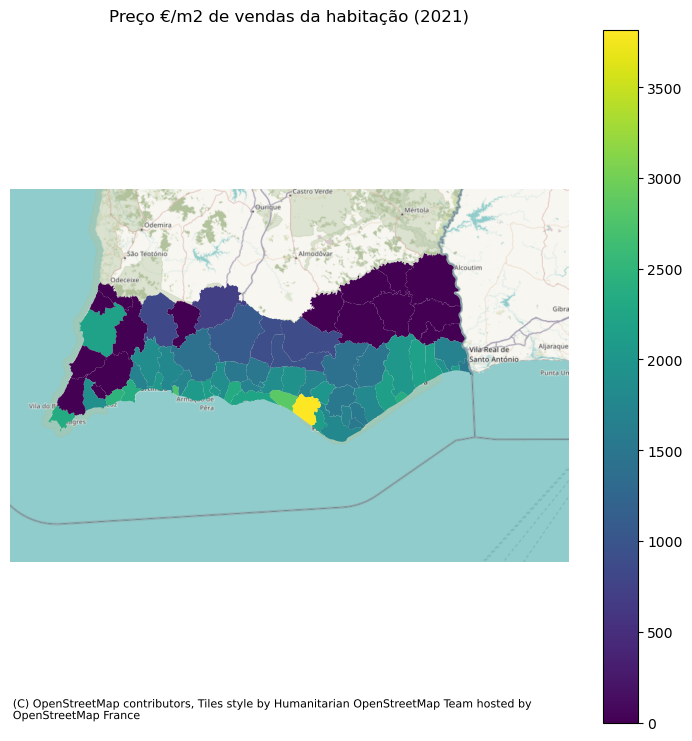

```python
figura, ax = plt.subplots(1, figsize=(9,9))

gdf_CAOP_Algarve_precoVenda.plot(ax=ax, column='2021_Total', legend=True)

cx.add_basemap(ax)

ax.set_axis_off()
ax.set_title('Preço €/m2 de vendas da habitação (2021)')
plt.axis('equal')
plt.show()
```

**Interpretação:** Os valores mais elevados concentram-se no litoral central e barlavento algarvio, destacando-se as freguesias de Quarteira e Almancil, onde os preços ultrapassam os 2.800 €/m². No interior, predominam preços mais baixos (inderiores a 1100 €/m²), com várias freguesias a roxo escuro, indicando ausência de valores registados. Este padrão evidencia uma forte diferenciação geográfica, com valores significativamente mais elevados nas zonas turísticas do litoral, contrastando com a menor dinâmica do mercado no interior algarvio.

```python
gdf_CAOP_Algarve_rendas["2021_rendas"].describe()
```

```
count     67.000000
mean     329.211940
std       91.264562
min        0.000000
25%      284.270000
50%      342.320000
75%      388.545000
max      507.410000
Name: 2021_rendas, dtype: float64
```

**Interpretação:** O valor médio das rendas no Algarve em 2021 foi de 329 €/mês, com valores a variar entre 0 € e 507 €/mês, refletindo diferenças significativas entre freguesias. A mediana de 342 € indica que metade das freguesias apresenta rendas inferiores a este valor, enquanto um quarto das freguesias tem rendas abaixo de 284 €, sugerindo zonas com valores bastante acessíveis. O desvio padrão de 91 € demonstra alguma dispersão nos valores, mas menor do que nos preços de venda, indicando uma menor desigualdade no mercado de arrendamento.

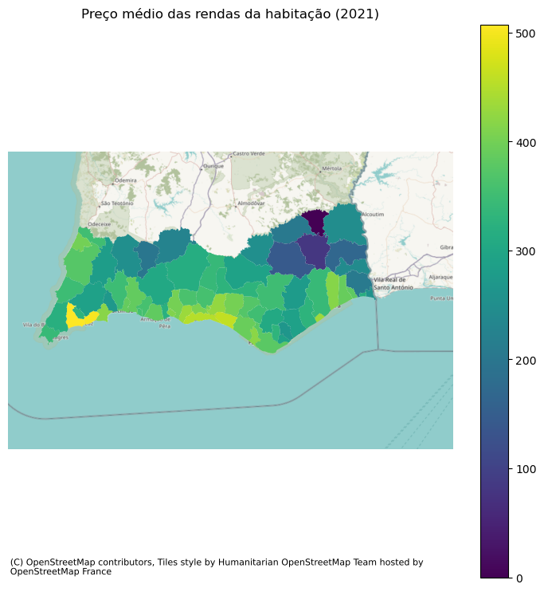

```python
figura, ax = plt.subplots(1, figsize=(9,9))

gdf_CAOP_Algarve_rendas.plot(ax=ax, column='2021_rendas', legend=True)

cx.add_basemap(ax)

ax.set_axis_off()
ax.set_title('Preço médio das rendas da habitação (2021)')
plt.axis('equal')
plt.show()
```

**Interpretação:** Os valores das rendas em 2021 são mais elevados ao longo da costa algarvia, destacando-se, sobretudo as zonas de Lagos, Albufeira, Quarteira e Vila do Bispo, onde ultrapassam os 450 €/mês. No interior, predominam valores mais baixos (maioria inferiores a 300 €/mês), nomeadamente em Alcoutim e Monchique. Algumas freguesias surgem a roxo escuro, indicando provável ausência de dados ou escassez de arrendamento registado. Existe assim um padrão geográfico que sugere uma forte correlação entre as rendas e a valorização turística, concentrando os preços mais elevados no litoral. Tal como no mercado de compra, verifica-se uma grande discrepância entre o litoral e o interior algarvio.

## Preço mediano por tipologia da habitação (2021)

### T0 ou T1

```python
gdf_CAOP_Algarve_tipologia["2021_T0 ou T1"].describe()
```

```
count      67.000000
mean      657.537313
std      1034.224733
min         0.000000
25%         0.000000
50%         0.000000
75%      1847.500000
max      3069.000000
Name: 2021_T0 ou T1, dtype: float64
```

**Interpretação:** O preço mediano das vendas de T0/T1 em 2021 no Algarve apresenta uma grande dispersão, com uma média de 657 €/m² e um desvio padrão elevado (1.034 €/m²), sugerindo discrepâncias significativas entre freguesias. O valor máximo atinge 3.069 €/m², refletindo a valorização em certas zonas, enquanto o mínimo é 0 €/m², indicando freguesias sem transações registadas. A mediana de 0 €/m² e o facto de 50% das freguesias não apresentarem valores sugerem um mercado reduzido para esta tipologia, concentrado apenas em algumas áreas.

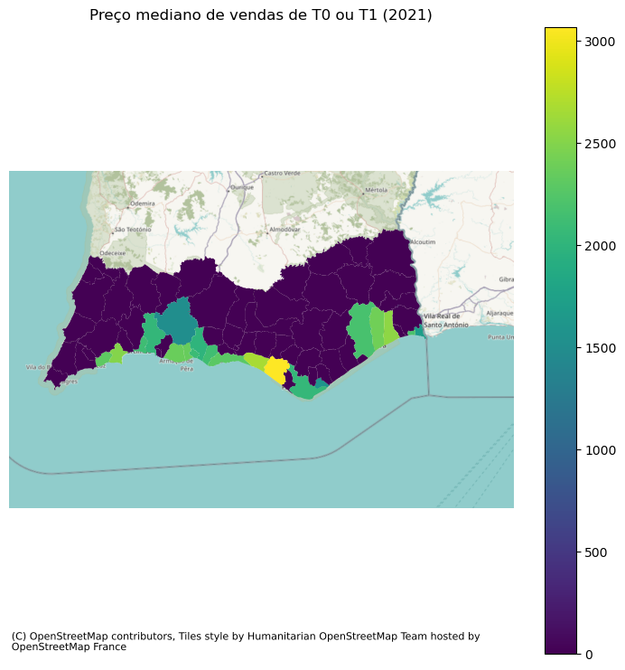

```python
## Tipologias: T0 ou T1

figura, ax = plt.subplots(1, figsize=(9,9))

gdf_CAOP_Algarve_tipologia.plot(ax=ax, column='2021_T0 ou T1', legend=True)

cx.add_basemap(ax)

ax.set_axis_off()
ax.set_title('Preço mediano de vendas de T0 ou T1 (2021)')
plt.axis('equal')
plt.show()
```

**Interpretação:** Os preços das habitações T0/T1 em 2021 apresentam uma forte concentração de freguesias sem valores registados, especialmente no interior algarvio e em algumas zonas costeiras (a roxo escuro). As freguesias com valores mais elevados localizam-se no litoral sul, destacando-se Albufeira, Vilamoura e algumas áreas de Portimão, onde os preços ultrapassam 2000 €/m². A ausência de valores na maioria das freguesias sugere um mercado reduzido para esta tipologia, possivelmente concentrado em áreas com maior procura turística. O padrão geográfico indica que as habitações T0/T1 são valorizadas em destinos turísticos e praticamente inexistentes no interior.

### T2

```python
gdf_CAOP_Algarve_tipologia["2021_T2"].describe()
```

```
count      67.000000
mean      881.761194
std      1003.416257
min         0.000000
25%         0.000000
50%         0.000000
75%      1777.000000
max      3374.000000
Name: 2021_T2, dtype: float64
```

**Interpretação:** O preço mediano das habitações T2 em 2021 apresenta uma média de 881 €/m², com um desvio padrão elevado (1003 €/m²), refletindo grande variação entre freguesias. O valor máximo atinge 3374 €/m², indicando preços elevados em algumas zonas, enquanto o mínimo é 0 €/m², sugerindo freguesias sem transações registadas. A mediana de 0 €/m² e o facto de 50% das freguesias não apresentarem valores indicam que o mercado de T2 está concentrado em poucas áreas, com uma distribuição espacial muito desigual.

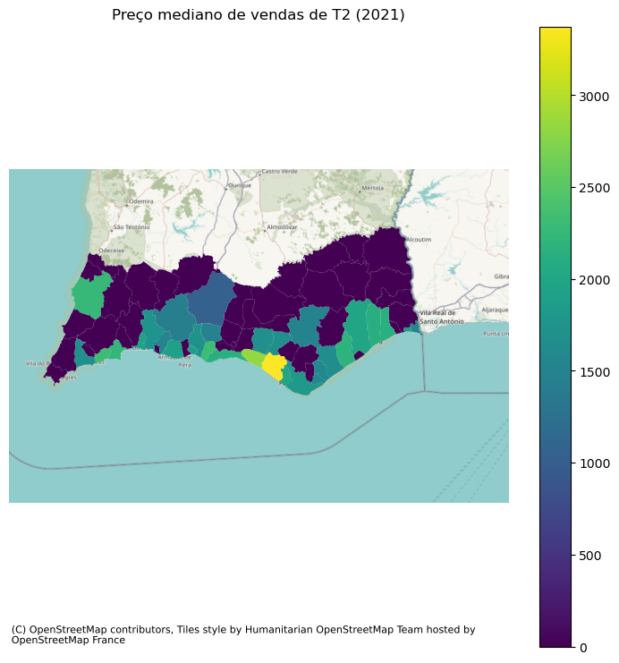

```python
## Tipologias: T2

figura, ax = plt.subplots(1, figsize=(9,9))

gdf_CAOP_Algarve_tipologia.plot(ax=ax, column='2021_T2', legend=True)

cx.add_basemap(ax)

ax.set_axis_off()
ax.set_title('Preço mediano de vendas de T2 (2021)')
plt.axis('equal')
plt.show()
```

### T3

```python
gdf_CAOP_Algarve_tipologia["2021_T3"].describe()
```

```
count      67.000000
mean      823.597015
std      1044.183980
min         0.000000
25%         0.000000
50%         0.000000
75%      1777.500000
max      3713.000000
Name: 2021_T3, dtype: float64
```

**Interpretação:** O preço mediano das habitações T3 em 2021 apresenta uma média de 823 €/m², ligeiramente inferior à dos T2, e um desvio padrão elevado (1044 €/m²), indicando forte variação entre freguesias. O valor máximo atinge 3713 €/m², refletindo a valorização em algumas áreas, enquanto o mínimo é 0 €/m², sugerindo a inexistência de valores em várias freguesias. A mediana de 0 €/m² e mais uma vez o facto de 50% das freguesias não apresentarem valores mostram que o mercado para esta tipologia não está uniformemente distribuído, sendo mais ativo em certas regiões do litoral.

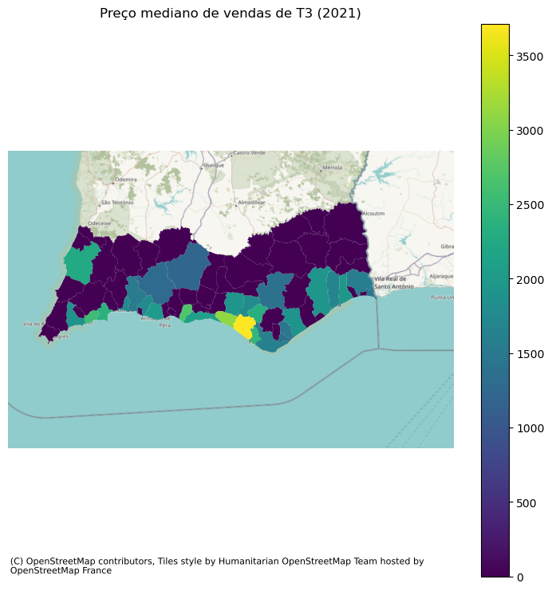

```python
## Tipologias: T3

figura, ax = plt.subplots(1, figsize=(9,9))

gdf_CAOP_Algarve_tipologia.plot(ax=ax, column='2021_T3', legend=True)

cx.add_basemap(ax)

ax.set_axis_off()
ax.set_title('Preço mediano de vendas de T3 (2021)')
plt.axis('equal')
plt.show()
```

### T4 ou mais

```python
gdf_CAOP_Algarve_tipologia["2021_T4 ou mais"].describe()
```

```
count      67.000000
mean      583.164179
std      1129.475134
min         0.000000
25%         0.000000
50%         0.000000
75%       702.000000
max      5645.000000
Name: 2021_T4 ou mais, dtype: float64
```

**Interpretação:** O preço mediano das habitações T4 ou mais em 2021 apresenta uma média de 583 €/m², sendo a tipologia com o valor médio mais baixo, mas também com a maior variação (desvio padrão de 1129 €/m²). O preço máximo atinge 5645 €/m², sugerindo a existência de propriedades de luxo em algumas freguesias, enquanto a mediana de 0 €/m² indica que mais de 50% das freguesias não registaram transações desta tipologia. Estes dados refletem um mercado imobiliário muito concentrado, com algumas freguesias a apresentarem valores muito elevados, enquanto a maioria não tem qualquer registo de venda de imóveis T4 ou +.

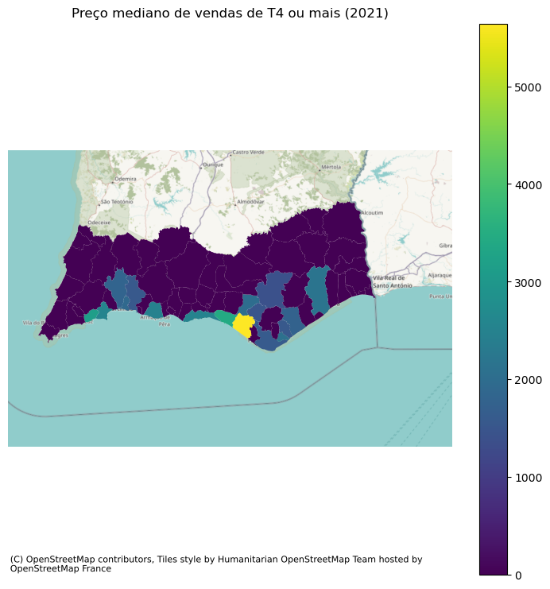

```python
## Tipologias: T4 ou mais

figura, ax = plt.subplots(1, figsize=(9,9))

gdf_CAOP_Algarve_tipologia.plot(ax=ax, column='2021_T4 ou mais', legend=True)

cx.add_basemap(ax)

ax.set_axis_off()
ax.set_title('Preço mediano de vendas de T4 ou mais (2021)')
plt.axis('equal')
plt.show()
```

# Classificação dos dados e visualização

```python
# ISTO JÁ ESTA EM CIMA E INTERPRETADO, ACHO QUE NAO FAZ SNETIDO TAR AQUI OUTRA VEZ
gdf_CAOP_Algarve_precoVenda['2021_Total'].describe().round(1)
```

```
count      67.0
mean     1407.4
std       924.8
min         0.0
25%       772.5
50%      1699.0
75%      2048.5
max      3818.0
Name: 2021_Total, dtype: float64
```

```python
## Exploração gráfica da distribuição dos dados, distribuiçao por dados iguais

classif = mc.EqualInterval(gdf_CAOP_Algarve_precoVenda['2021_Total'], k=7)
classif
```

```
EqualInterval

     Interval        Count
--------------------------
[   0.00,  545.43] |    16
( 545.43, 1090.86] |     6
(1090.86, 1636.29] |     9
(1636.29, 2181.71] |    26
(2181.71, 2727.14] |     7
(2727.14, 3272.57] |     2
(3272.57, 3818.00] |     1
```

```python
## Distribuição por quartis
classif_quart = mc.Quantiles(gdf_CAOP_Algarve_precoVenda['2021_Total'], k=5)
classif_quart
```

```
Quantiles

     Interval        Count
--------------------------
[   0.00,    0.00] |    16
(   0.00, 1527.40] |    11
(1527.40, 1830.80] |    13
(1830.80, 2114.40] |    13
(2114.40, 3818.00] |    14
```

Há 16 freguesias sem dados sobre os preços de habitação. 11 freguesias cujos preços médios por m2 vai até aos 1527,40 euros.

```python
classif_quart.bins
```

```
array([   0. , 1527.4, 1830.8, 2114.4, 3818. ])
```

[figure not shown]

```python
f, ax = plt.subplots(1)

sns.kdeplot(gdf_CAOP_Algarve_precoVenda['2021_Total'], fill=True)

sns.rugplot(gdf_CAOP_Algarve_precoVenda['2021_Total'], alpha=0.5)

for cut in classif_quart.bins:
    plt.axvline(cut, color='red', linewidth=0.75)
```

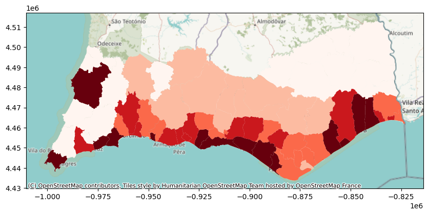

```python
# Padrões geográficos
figura, ax = plt.subplots(figsize = (10,10) )
ax.set_aspect('equal')

gdf_CAOP_Algarve_precoVenda.plot(ax=ax,zorder=1,
                      # marker="s",
                      column='2021_Total',
                      scheme='Quantiles',
                      # k=7,
                      cmap=plt.cm.Reds,
                      linewidth=0 )

cx.add_basemap(ax)
```

```python
#Desvio padrão médio

classif = mc.StdMean(gdf_CAOP_Algarve_precoVenda['2021_Total'])
classif
```

```
StdMean

     Interval        Count
--------------------------
(   -inf, -442.11] |     0
(-442.11,  482.65] |    16
( 482.65, 2332.16] |    43
(2332.16, 3256.91] |     7
(3256.91, 3818.00] |     1
```

## Matrizes e pesos de vizinhança

Uma vez que temos dados omissos (16 freguesias sem dados de preço mediano de vendas por m2), vamos aplicar a imputação média dos vizinhos. Nota: os dados omissos são os que apresentam valores a zero.

```python
gdf_CAOP_Algarve_precoVenda.head(3)
```

|  | DICOFRE | Freguesia | Municipio | Distrito | Area_ha | Des_Simpli | geometry | Localizacao | Codigo_identificador | CODIGO | 2023_Total | 2023_Novos | 2023_Existentes | 2022_Total | 2022_Novos | 2022_Existentes | 2021_Total | 2021_Novos | 2021_Existentes |
| --- | --- | --- | --- | --- | --- | --- | --- | --- | --- | --- | --- | --- | --- | --- | --- | --- | --- | --- | --- |
| 0 | 080102 | Guia | Albufeira | Faro | 2496.60 | Guia | MULTIPOLYGON (((-921625.291 4459287.899, -9216... | Guia | 150080102 | 080102 | 2829.0 | 2876.0 | 2824.0 | 2580.0 | 0.0 | 2562.0 | 2334.0 | 1558.0 | 2412.0 |
| 1 | 080103 | Paderne | Albufeira | Faro | 5256.17 | Paderne | MULTIPOLYGON (((-907971.652 4465405.347, -9079... | Paderne | 150080103 | 080103 | 1633.0 | 0.0 | 1552.0 | 1653.0 | 0.0 | 1631.0 | 1510.0 | 0.0 | 1510.0 |
| 2 | 080104 | Ferreiras | Albufeira | Faro | 2195.96 | Ferreiras | MULTIPOLYGON (((-910980.514 4458695.031, -9109... | Ferreiras | 150080104 | 080104 | 2079.0 | 0.0 | 2009.0 | 2022.0 | 0.0 | 2022.0 | 1700.0 | 0.0 | 1758.0 |

No contexto do Algarve, o **uso do Rook** é mais adequado porque considera como vizinhas apenas as freguesias que partilham uma fronteira, refletindo melhor a influência espacial direta nos preços da habitação. O critério Queen incluiria freguesias que apenas se tocam nos vértices, podendo criar conexões menos realistas entre zonas sem interação significativa.

```python
w_rook_gdf_CAOP_Algarve_precoVenda = weights.contiguity.Rook.from_dataframe(gdf_CAOP_Algarve_precoVenda, use_index=True)
```

Como a dataframe **gpd_CAOP_Algarve_precoVenda** não tem *missing values*, ou seja, valores vazios, os pesos da matriz vizinhança vão ser atribuidos aos valores zeros, que efectivamente significam que não há dados dos preços medianos de vendas naquela(s) freguesia(s).

```python
# Função para aplicar pesos aos valores zero
def apply_weights_to_zero_values(gdf, weights, colname):
    zero_mask = gdf[colname] == 0
    for index, row in gdf[zero_mask].iterrows():
        neighbors = list(weights.neighbors[index])  # Obter os vizinhos como lista
        if neighbors:
            values = gdf.loc[neighbors, colname].values
            gdf.at[index, colname] = values.mean() if len(values) > 0 else 0
    return gdf

gdf_CAOP_Algarve_precoVenda['2021_imputacao'] = gdf_CAOP_Algarve_precoVenda['2021_Total']
gdf_CAOP_Algarve_precoVenda = apply_weights_to_zero_values(
    gdf_CAOP_Algarve_precoVenda, w_rook_gdf_CAOP_Algarve_precoVenda, colname='2021_imputacao'
)

gdf_CAOP_Algarve_precoVenda[['2021_imputacao', '2021_Total']]
```

|  | 2021_imputacao | 2021_Total |
| --- | --- | --- |
| 0 | 2334.000 | 2334.0 |
| 1 | 1510.000 | 1510.0 |
| 2 | 1700.000 | 1700.0 |
| 3 | 2233.000 | 2233.0 |
| 4 | 0.000 | 0.0 |
| ... | ... | ... |
| 62 | 2333.000 | 2333.0 |
| 63 | 1573.975 | 0.0 |
| 64 | 2136.000 | 2136.0 |
| 65 | 1533.000 | 1533.0 |
| 66 | 2076.000 | 2076.0 |

67 rows × 2 columns

#### Comparar resultados após imputação de pesos

```python
gdf_CAOP_Algarve_precoVenda['2021_Total'].describe().round(1)
```

```
count      67.0
mean     1407.4
std       924.8
min         0.0
25%       772.5
50%      1699.0
75%      2048.5
max      3818.0
Name: 2021_Total, dtype: float64
```

```python
gdf_CAOP_Algarve_precoVenda['2021_imputacao'].describe().round(1)
```

```
count      67.0
mean     1623.6
std       688.5
min         0.0
25%      1356.2
50%      1700.0
75%      2048.5
max      3818.0
Name: 2021_imputacao, dtype: float64
```

```python
# Registam-se duas freguesias com valores de 0 €/m², que serão mantidas na análise por refletirem a realidade do mercado imobiliário na região, indicando áreas com baixa ou inexistente atividade de transações.
print(gdf_CAOP_Algarve_precoVenda[gdf_CAOP_Algarve_precoVenda['2021_imputacao'] == 0][['DICOFRE', 'Freguesia']])
```

```
  DICOFRE     Freguesia
4  080202         Giões
5  080203  Martim Longo
```

- A média aumentou de 1407,40 para 1623,60;
- O desvio-padrão diminuiu de 924,80 para 688,50;
- O primeiro quartil alterou de 772,50 para 1356,20

```python
classif_quart=mc.Quantiles(gdf_CAOP_Algarve_precoVenda['2021_imputacao'], k=5)
classif_quart
```

```
Quantiles

     Interval        Count
--------------------------
[   0.00, 1003.07] |    14
(1003.07, 1530.60] |    13
(1530.60, 1856.40] |    13
(1856.40, 2114.40] |    13
(2114.40, 3818.00] |    14
```

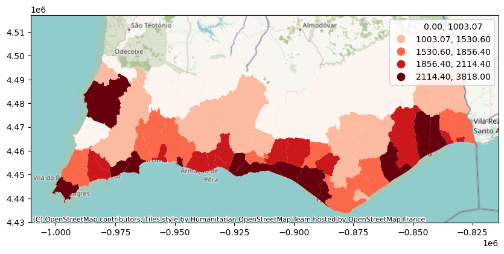

```python
# Padrões geográficos
figura, ax = plt.subplots(figsize = (10,10) )
ax.set_aspect('equal')

gdf_CAOP_Algarve_precoVenda.plot(ax=ax,zorder=1,
                      # marker="s",
                      column='2021_imputacao',
                      scheme='Quantiles',
                      # k=7,
                      cmap=plt.cm.Reds,
                      linewidth=0,
                      legend=True)

cx.add_basemap(ax)
```

**Interpretação:** Observa-se uma clara diferenciação geográfica, onde as freguesias com valores mais elevados (tons mais escuros) se concentram no litoral, especialmente no centro e barlavento algarvio. Já as zonas com preços mais baixos (tons mais claros) situam-se predominantemente no interior, indicando uma menor valorização do mercado imobiliário. Estes padrões sugerem uma forte influência do turismo e proximidade ao mar na valorização dos imóveis.

# Dependência Espacial

```python
precoM2_lag = weights.lag_spatial(w_rook_gdf_CAOP_Algarve_precoVenda, gdf_CAOP_Algarve_precoVenda['2021_imputacao'] )
gdf_CAOP_Algarve_precoVenda["2021_imputacao_lag"] = precoM2_lag
```

```python
# "Normalizar" (cálculo de z-scores) as variáveis (original imputada e desfasada)
gdf_CAOP_Algarve_precoVenda['2021_imputacao_std'] = (
    gdf_CAOP_Algarve_precoVenda['2021_imputacao'] - gdf_CAOP_Algarve_precoVenda['2021_imputacao'].mean()
) / gdf_CAOP_Algarve_precoVenda['2021_imputacao'].std()

gdf_CAOP_Algarve_precoVenda['2021_imputacao_lag_std'] = (
    gdf_CAOP_Algarve_precoVenda['2021_imputacao_lag'] - gdf_CAOP_Algarve_precoVenda['2021_imputacao_lag'].mean()
) / gdf_CAOP_Algarve_precoVenda['2021_imputacao_lag'].std()
```

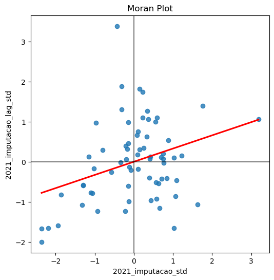

```python
# Moran Plot
f, ax = plt.subplots(1, figsize=(6, 6))
sns.regplot(x='2021_imputacao_std', y='2021_imputacao_lag_std',
                ci=None, data=gdf_CAOP_Algarve_precoVenda, line_kws={'color':'r'})
ax.axvline(0, c='k', alpha=0.5)
ax.axhline(0, c='k', alpha=0.5)
ax.set_title('Moran Plot')
plt.show()
```

**Interpretação:** O Moran Plot revela uma autocorrelação espacial positiva, indicando que freguesias com preços elevados tendem a estar próximas de outras também com valores altos, enquanto freguesias com preços mais baixos se agrupam entre si. A inclinação da reta de regressão sugere uma relação espacial moderada, com alguma dispersão dos pontos. Apesar da variabilidade, observa-se um padrão espacial onde os valores do mercado imobiliário não estão distribuídos aleatoriamente, mas sim influenciados pelos valores das freguesias vizinhas.

# Autocorrelação Espacial - Global

```python
# Calcular o indice de Moran
morans_I = Moran(gdf_CAOP_Algarve_precoVenda['2021_imputacao_std'], w_rook_gdf_CAOP_Algarve_precoVenda)

print(f"Índice de Moran: {morans_I.I:.4f}")
print(f"p-valor: {morans_I.p_sim:.4f}")
print(f"z-score: {morans_I.z_sim:.4f}")
```

```
Índice de Moran: 0.5167
p-valor: 0.0010
z-score: 6.5130
```

**Interpretação:** O Índice de Moran Global de 0.5167 indica uma autocorrelação espacial positiva moderada nos preços da habitação, ou seja, freguesias com preços elevados tendem a estar próximas de outras com valores altos, e o mesmo acontece com preços baixos. O p-valor de 0.0010 mostra que esta autocorrelação é estatisticamente significativa ao nível de 1%, confirmando que os preços não estão distribuídos aleatoriamente. O z-score de 6.5130 reforça essa evidência, indicando que o padrão espacial observado é altamente improvável de ter ocorrido por acaso.

### **Inferência de Moran**

- Partiremos das seguintes questões:

H0 = Não existe autocorrelação espacial significativa nos preços da habitação. Os valores estão distribuídos aleatoriamente no espaço.

H1 = Existe autocorrelação espacial significativa nos preços da habitação, indicando um padrão espacial estruturado.

```python
# Teste de permutação para Moran
morans_I_perm = Moran(gdf_CAOP_Algarve_precoVenda['2021_imputacao_std'],
                      w_rook_gdf_CAOP_Algarve_precoVenda,
                      permutations=999)

print(f"Índice de Moran: {morans_I_perm.I:.4f}")
print(f"p-valor: {morans_I_perm.p_sim:.4f}")
print(f"z-score: {morans_I_perm.z_sim:.4f}")
```

```
Índice de Moran: 0.5167
p-valor: 0.0010
z-score: 6.5200
```

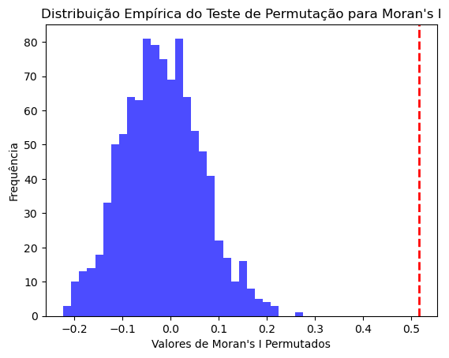

```python
# Visualizar
plt.hist(morans_I_perm.sim, bins=30, alpha=0.7, color='blue')  # Distribuição empírica
plt.axvline(morans_I_perm.I, color='red', linestyle='dashed', linewidth=2)  # Valor observado
plt.title("Distribuição Empírica do Teste de Permutação para Moran's I")
plt.xlabel("Valores de Moran's I Permutados")
plt.ylabel("Frequência")
plt.show()
```

**Interpretação:** O teste de permutação confirma a existência de autocorrelação espacial positiva significativa nos preços de venda por m² no Algarve. O Moran’s I observado (0.5167) está muito acima da distribuição empírica gerada aleatoriamente, com um p-valor < 0.01, o que nos leva a rejeitar a hipótese nula (H0) de ausência de padrão espacial. Assim, aceitamos a hipótese alternativa (H1), concluindo que os preços da habitação não estão distribuídos aleatoriamente, mas seguem um padrão espacial significativo.

# Autocorrelação Espacial - Local

```python
# Calcular LISA
moran_local_precoVenda = Moran_Local(gdf_CAOP_Algarve_precoVenda['2021_imputacao_std'], w_rook_gdf_CAOP_Algarve_precoVenda)
```

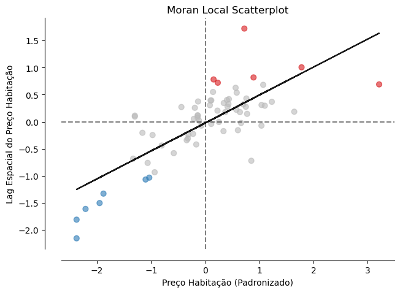

```python
# scatterplot di LISA
figura, ax = moran_scatterplot(moran_local_precoVenda, p=0.05)
ax.set_xlabel('Preço Habitação (Padronizado)')
ax.set_ylabel('Lag Espacial do Preço Habitação')
plt.show()
```

```python
print(len(moran_local_precoVenda.Is))  # Ver quantos pontos foram considerados
print(len(gdf_CAOP_Algarve_precoVenda))  # Ver quantas freguesias total
```

```
67
67
```

**Interpretação:** A inclinação positiva da reta sugere que freguesias com preços elevados tendem a estar próximas de outras com preços igualmente elevados (clusters de High-High) e o mesmo ocorre para preços baixos (Low-Low). Os pontos coloridos indicam áreas estatisticamente significativas, onde a dependência espacial é mais forte. Já os pontos dispersos mostram freguesias sem padrões espaciais claros.

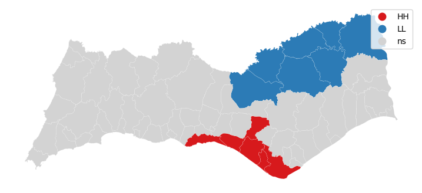

```python
# Gerar o mapa LISA para os preços de venda da habitação
figura, ax = lisa_cluster(moran_local_precoVenda, gdf_CAOP_Algarve_precoVenda, p=0.05, figsize=(9,9))

plt.show()
```

**Interpretação:** O mapa LISA revela padrões espaciais na distribuição dos preços da habitação. Observa-se um cluster alto-alto (HH) no litoral sul, indicando freguesias com preços elevados próximas umas das outras, provavelmente devido à procura turística e localização privilegiada. No interior, verifica-se um cluster baixo-baixo (LL), onde freguesias com preços mais reduzidos se agrupam, refletindo menor atratividade do mercado. As restantes freguesias não apresentam correlação espacial significativa, sugerindo uma distribuição mais dispersa dos preços nessas áreas.

# Conclusão

**Análise dos Preços Médios de Habitação no Algarve**

Resumo da Análise Este estudo aprofundou a compreensão dos preços médios de venda de habitação na Região Algarve, utilizando as freguesias como unidades de análise. Com base em três indicadores principais sendo valor mediano das vendas por metro quadrado, valor médio das rendas e preços por tipologia de imóvel, buscou-se identificar padrões e tendências que explicam a dinâmica do mercado imobiliário na região.

*Principais Insights*

- Confirmou-se assim que as freguesias costeiras e turísticas concentram os preços mais altos, refletindo a forte influência do turismo e da procura por residências secundárias. Essas áreas são polos de atração para investidores e compradores, consolidando-se como as mais valorizadas da região.
- Enquanto os preços mais elevados da compra de habitação estão mais concentrados na freguesia de Almancil e vizinhança, os preços médios de arrendamento, por outro lado, estão mais uniformes ao longo da região costeira, sendo a freguesa de Budens a que apresenta valor mais elevado em termos de arrendamento.
- Relativamente às tipologias, casas de maior dimensão estão onde o preço mediano de compra é mais elevado. A freguesia de Almancil tem grande concentração de habitações com todas as tipologias. Esta concentração expande-se em simultâneo ao logo das freguesias vizinhas. Poderá a variável preços medianos por tipologias ter explicar os preços médios, mas ainda não sabemos o quanto explica.
- Observou-se que os preços das habitações seguem padrões bem definidos, com agrupamentos de freguesias de alto valor imobiliário. Isso reforça a ideia de que fatores geográficos, como a proximidade do mar ou localizações atrativas, e económicos, como a infraestrutura turística, grandes centros hurbanos, são determinantes para a valorização das propriedades.

**Considerações Finais e Perspectivas Futuras**

Na próxima fase e na sequência da análise exploratória aos preços e rendas medianos de habitação da Região do Algarve, podemos considerar outras variáveis para explicativas e independentes como:

- o rácio de idosos na população total de cada freguesia: para confirmar de a pouca ou muita dinamização habitacional (bem como a ausência de dados) é justificada pelo envelhecimento da população residente;
- um indicador que seja relativo à atividade turística (por exemplo: número de restaurantes e hotelaria presentes no território) para evidenciar se a percepção do impacto do turismo é estatisticamente significativo nos preços de habitação. Porque a atividade turística é um grande motor económico em termos de empregabilidade e onde há emprego, há também pessoas a procurar habitação;

Outra nota importante é: devido à ausência de dados em algumas freguesias, considerar anos posteriores ou redefinir a escala de análise para os municípios. Isto também para reforçar se o padrão aqui identificado ao nível das freguesias (zona costeira vs zona montanhosa) é muito idêntico ao nível dos municpios e em que zonas.

# Bibliografia

- Notebook e material disponibilizado pelo professor
- [Exploratory Analysis of Spatial Data: Spatial Autocorrelation](https://nbviewer.org/github/pysal/esda/blob/main/notebooks/Spatial%20Autocorrelation%20for%20Areal%20Unit%20Data.ipynb)